# Projet_analyse_de_données

Aziz_DHIF

2024-12-29

## Notre sujet d’étude est l’obésité en tunisie

Nous avons 3 blocs , le premier bloc concerne l’hygiène de vie (question 1 à 10), le deuxième bloc concerne l’alimentation (question 1 à 10), le troisième blocs avec des questions oui ou non(question 1 à 11) et le dernier bloc sont quatres questions qui concernent le sexe, l’age , le poids et la taille

## 1)Téléchargement et Description des données:

```r
#préparation  des données

data=read.csv("C:\\Users\\Aziz Dhif\\Documents\\projet analyse de donnée.csv",header=TRUE,sep=",")
```

```r
names(data) # visualisations des noms des colonnes
```

```
##  [1] "Horodateur"
##  [2] "Sur.une.échelle.de.1.à.5..merci.d.évaluer.à.quel.point.vous.répondez.à.ces.critères..je.pratique.du.sport."
##  [3] "Sur.une.échelle.de.1.à.5..merci.d.évaluer.à.quel.point.vous.répondez.à.ces.critères..je..fait.attention.à.mon.alimentation."
##  [4] "Sur.une.échelle.de.1.à.5..merci.d.évaluer.à.quel.point.vous.répondez.à.ces.critères..je.dors.au.moins.7.heures.par.jours."
##  [5] "Sur.une.échelle.de.1.à.5..merci.d.évaluer.à.quel.point.vous.répondez.à.ces.critères..j.essaie.toujours.de.gérer.mon.stress."
##  [6] "Sur.une.échelle.de.1.à.5..merci.d.évaluer.à.quel.point.vous.répondez.à.ces.critères..je.fume.régulièrement.des.cigarettes.."
##  [7] "Sur.une.échelle.de.1.à.5..merci.d.évaluer.à.quel.point.vous.répondez.à.ces.critères..je.bois.régulièrement.de.l.alcool."
##  [8] "Sur.une.échelle.de.1.à.5..merci.d.évaluer.à.quel.point.vous.répondez.à.ces.critères..je.fait.attention.à.ma.santé.et.je.suis.les.recommandations.médical.."
##  [9] "Sur.une.échelle.de.1.à.5..merci.d.évaluer.à.quel.point.vous.répondez.à.ces.critères..je.fait.attention.à.ma.santé.mentale..je.vois.des.amis..je.pratique.des.activités.qui.me.font.du.bien.."
## [10] "Sur.une.échelle.de.1.à.5..merci.d.évaluer.à.quel.point.vous.répondez.à.ces.critères..j.essaie.de.me.déplacer.à.pied.."
## [11] "Sur.une.échelle.de.1.à.5..merci.d.évaluer.à.quel.point.vous.répondez.à.ces.critères..je..me.pèse.régulièrement.pour.faire.attention.à.mon.poid."
## [12] "Sur.une.échelle.de.1.à.5.merci.d.évaluer.à.quel.point.vous.répondez.à.ces.critères..je.consomme.des.fruits.et.des.légumes."
## [13] "Sur.une.échelle.de.1.à.5.merci.d.évaluer.à.quel.point.vous.répondez.à.ces.critères..je.consomme.une.bonne.variété.de.source.de.protéine."
## [14] "Sur.une.échelle.de.1.à.5.merci.d.évaluer.à.quel.point.vous.répondez.à.ces.critères..je.limite.ma.consommation.du..sucre.ajouté."
## [15] "Sur.une.échelle.de.1.à.5.merci.d.évaluer.à.quel.point.vous.répondez.à.ces.critères..je.privilège.les.aliments.complet.farine.complète...pattes.complète..."
```

[output cut: 21 more lines]

```r
data=data[,-1]#on enleve la premiere colonne qui correspond à la date à laquelle l'inividu a remplit le formulaire
head(data)
```

```
##   Sur.une.échelle.de.1.à.5..merci.d.évaluer.à.quel.point.vous.répondez.à.ces.critères..je.pratique.du.sport.
## 1                                                                                                          4
## 2                                                                                                          1
## 3                                                                                                          3
## 4                                                                                                          1
## 5                                                                                                          1
## 6                                                                                                          3
##   Sur.une.échelle.de.1.à.5..merci.d.évaluer.à.quel.point.vous.répondez.à.ces.critères..je..fait.attention.à.mon.alimentation.
## 1                                                                                                                           3
## 2                                                                                                                           2
## 3                                                                                                                           3
## 4                                                                                                                           4
## 5                                                                                                                           3
## 6                                                                                                                           3
##   Sur.une.échelle.de.1.à.5..merci.d.évaluer.à.quel.point.vous.répondez.à.ces.critères..je.dors.au.moins.7.heures.par.jours.
```

[output cut: 209 more lines]

```r
names(data)=c("sport","aliment","sommeil","stress","fumer","alcool","santé","Smentale","bouger","peser","fg","proteine","sucre","complet","hydrater","grignS","fastF","informéA","grignR","stressF","Tg","OE","OV","Tc","allergie","Mchron","SSPORT","FSpoids","fumez","alcool","surpoids","sexe","age","poids","taille")#on renomme les colonnes  pour rendre les cartes factorieles plus visibles
names(data)
```

```
##  [1] "sport"    "aliment"  "sommeil"  "stress"   "fumer"    "alcool"
##  [7] "santé"    "Smentale" "bouger"   "peser"    "fg"       "proteine"
## [13] "sucre"    "complet"  "hydrater" "grignS"   "fastF"    "informéA"
## [19] "grignR"   "stressF"  "Tg"       "OE"       "OV"       "Tc"
## [25] "allergie" "Mchron"   "SSPORT"   "FSpoids"  "fumez"    "alcool"
## [31] "surpoids" "sexe"     "age"      "poids"    "taille"
```

```r
head(data)
```

```
##   sport aliment sommeil stress fumer alcool santé Smentale bouger peser fg
## 1     4       3       4      4     1      2     4        4      4     1  3
## 2     1       2       2      2     2      2     2        2      1     1  2
## 3     3       3       2      1     1      1     5        5      5     5  3
## 4     1       4       5      3     1      1     4        5      5     1  5
## 5     1       3       2      2     1      1     4        4      4     3  4
## 6     3       3       5      2     2      1     3        3      2     4  4
##   proteine sucre complet hydrater grignS fastF informéA grignR stressF  Tg  OE
## 1        3     2       1        3      4     4        3      4       4 non non
## 2        2     2       2        2      1     1        1      1       1 non non
## 3        5     5       2        4      1     4        4      2       5 non non
## 4        3     1       1        4      5     4        5      2       5 non non
## 5        3     4       2        4      2     1        4      2       2 non non
## 6        4     3       3        4      5     1        4      1       1 non non
##    OV  Tc allergie Mchron SSPORT FSpoids fumez alcool surpoids  sexe age poids
## 1 non non      non    non    non     non   non    oui      non Femme  23    65
## 2 non non      oui    non    non     oui   oui    oui      non homme  56    78
## 3 non non      non    oui    non     non   non    non      oui homme  46    96
## 4 non non      non    non    non     oui   non    non      non Femme  21    49
## 5 non non      non    non    non     oui   non    non      non Femme  23    62
## 6 non non      non    non    non     oui   oui    oui      non homme  40    73
##   taille
## 1    180
## 2    176
## 3    178
## 4    170
## 5    163
## 6    176
```

```r
summary(data)
```

```
##      sport          aliment        sommeil          stress          fumer
##  Min.   :1.000   Min.   :1.00   Min.   :1.000   Min.   :1.000   Min.   :1.000
##  1st Qu.:1.000   1st Qu.:2.00   1st Qu.:2.000   1st Qu.:2.000   1st Qu.:1.000
##  Median :2.000   Median :3.00   Median :3.000   Median :3.000   Median :1.000
##  Mean   :2.425   Mean   :2.77   Mean   :3.023   Mean   :2.678   Mean   :1.977
##  3rd Qu.:3.000   3rd Qu.:4.00   3rd Qu.:4.000   3rd Qu.:3.500   3rd Qu.:3.000
##  Max.   :5.000   Max.   :5.00   Max.   :5.000   Max.   :5.000   Max.   :5.000
##      alcool          santé          Smentale         bouger
##  Min.   :1.000   Min.   :1.000   Min.   :1.000   Min.   :1.000
##  1st Qu.:1.000   1st Qu.:2.000   1st Qu.:2.000   1st Qu.:1.000
##  Median :1.000   Median :3.000   Median :3.000   Median :2.000
##  Mean   :1.678   Mean   :2.747   Mean   :3.069   Mean   :2.517
##  3rd Qu.:2.000   3rd Qu.:4.000   3rd Qu.:4.000   3rd Qu.:3.500
##  Max.   :5.000   Max.   :5.000   Max.   :5.000   Max.   :5.000
##      peser             fg           proteine         sucre         complet
##  Min.   :1.000   Min.   :1.000   Min.   :1.000   Min.   :1.00   Min.   :1.000
##  1st Qu.:1.000   1st Qu.:2.000   1st Qu.:2.000   1st Qu.:2.00   1st Qu.:1.000
##  Median :2.000   Median :3.000   Median :3.000   Median :3.00   Median :2.000
##  Mean   :2.494   Mean   :3.287   Mean   :3.103   Mean   :2.69   Mean   :2.391
##  3rd Qu.:3.000   3rd Qu.:4.000   3rd Qu.:4.000   3rd Qu.:4.00   3rd Qu.:3.000
##  Max.   :5.000   Max.   :5.000   Max.   :5.000   Max.   :5.00   Max.   :5.000
##     hydrater         grignS          fastF          informéA        grignR
##  Min.   :1.000   Min.   :1.000   Min.   :1.000   Min.   :1.00   Min.   :1.000
##  1st Qu.:2.000   1st Qu.:2.000   1st Qu.:1.000   1st Qu.:2.00   1st Qu.:1.000
##  Median :3.000   Median :3.000   Median :2.000   Median :3.00   Median :2.000
##  Mean   :3.057   Mean   :2.805   Mean   :2.517   Mean   :3.08   Mean   :2.322
##  3rd Qu.:4.000   3rd Qu.:4.000   3rd Qu.:3.000   3rd Qu.:4.00   3rd Qu.:3.000
##  Max.   :5.000   Max.   :5.000   Max.   :5.000   Max.   :5.00   Max.   :5.000
##     stressF          Tg                 OE                 OV
##  Min.   :1.00   Length:87          Length:87          Length:87
##  1st Qu.:1.00   Class :character   Class :character   Class :character
##  Median :2.00   Mode  :character   Mode  :character   Mode  :character
##  Mean   :2.54
##  3rd Qu.:4.00
##  Max.   :5.00
##       Tc              allergie            Mchron             SSPORT
##  Length:87          Length:87          Length:87          Length:87
##  Class :character   Class :character   Class :character   Class :character
##  Mode  :character   Mode  :character   Mode  :character   Mode  :character
##
##
##
##    FSpoids             fumez              alcool            surpoids
##  Length:87          Length:87          Length:87          Length:87
##  Class :character   Class :character   Class :character   Class :character
##  Mode  :character   Mode  :character   Mode  :character   Mode  :character
##
##
##
##      sexe                age           poids            taille
##  Length:87          Min.   :21.0   Min.   : 49.00   Min.   : 42.0
##  Class :character   1st Qu.:27.0   1st Qu.: 67.00   1st Qu.:164.5
##  Mode  :character   Median :42.0   Median : 75.00   Median :172.0
##                     Mean   :42.6   Mean   : 78.68   Mean   :168.2
##                     3rd Qu.:55.5   3rd Qu.: 85.00   3rd Qu.:178.5
##                     Max.   :69.0   Max.   :148.00   Max.   :195.0
```

## 2)ACP sur le bloc hygiène de vie

## 2)1)Intêret de l’Acp:

Etude des individus : deux individus sont proches s’ils ont des hygiènes de vie similaires. On s’intéresse à la variabilité entre individus. Y a-t-il des similarités entre les individus pour toutes les variables ? Peut-on établir des profils d’individu ? Peut-on opposer un groupe d’individus à un autre ?

Etude des variables : on étudie les liaisons linéaires entre les variables. Les objectifs sont de résumer la matrice des corrélations et de chercher des variables synthétiques: peut-on résumer l’hygiène de vie des individus par un petit nombre de variables ?

Lien entre les deux études : peut-on caractériser des groupes d’individus par des variables ?

## 2)2)Pertinence de l’acp

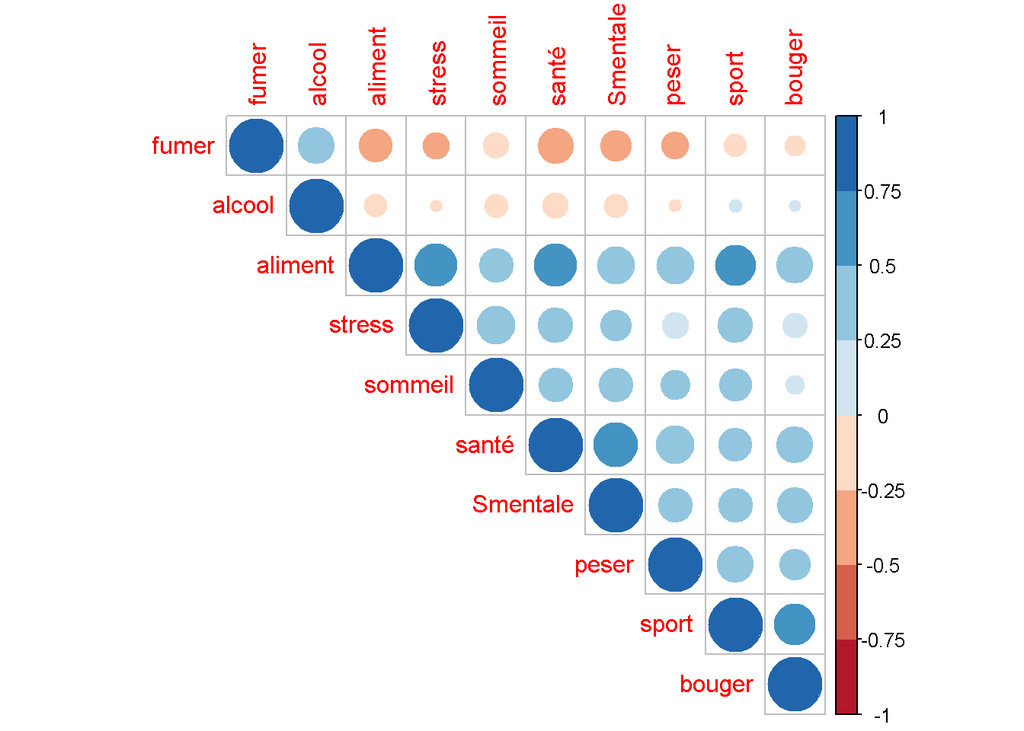

```r
library(corrplot)
X=as.matrix(data[,c(1:10)])
M<-cor(X)
library(RColorBrewer)
corrplot(M, type="upper", order="hclust", col=brewer.pal(n=8, name="RdBu"))
```

les variables sont significativement corrélées , notre ACP est donc pertinente.

```r
library(FactoMineR)
library(factoextra)
```

```r
res.pca=PCA(data[,c(1:10,32:35)],ncp = 5,quanti.sup = 12:14,quali.sup=11,graph=F) #sexe, age, poids et taille sont des variables supplémentaires
```

## 2)3)Choix du nombre d’axe

```r
head(res.pca$eig)
```

```
##        eigenvalue percentage of variance cumulative percentage of variance
## comp 1  4.2915711              42.915711                          42.91571
## comp 2  1.4491324              14.491324                          57.40704
## comp 3  1.0085118              10.085118                          67.49215
## comp 4  0.7205424               7.205424                          74.69758
## comp 5  0.6562048               6.562048                          81.25963
## comp 6  0.5791147               5.791147                          87.05077
```

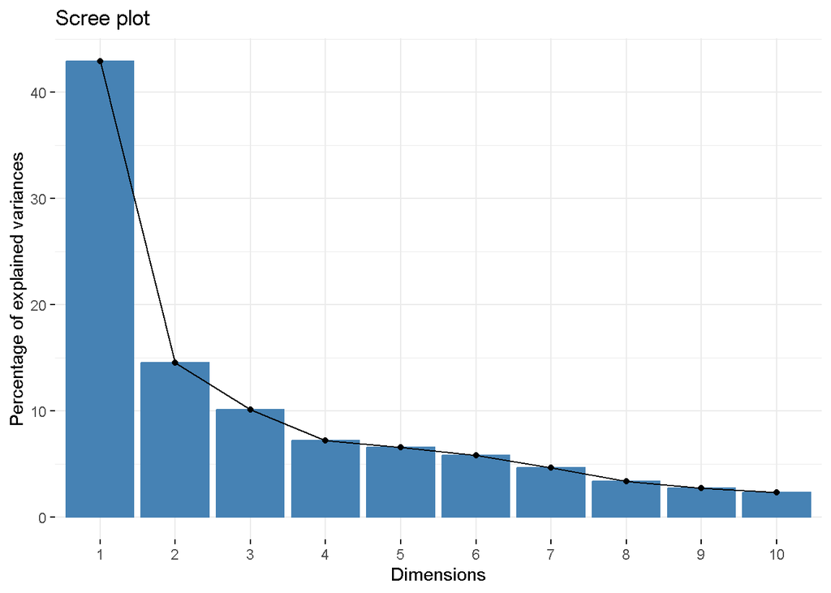

```r
fviz_screeplot(res.pca, ncp=10)
```

1. Critère de kaiser : on remarque qu’il y a 3 axes dont les valeurs propres sont supérieures à 1 donc on retient 3 axes d’après ce critère.
2. Critère du taux d’inertie cumulée : On remarque que le taux d’inertie cumulé des 2 premiers axes est de 57.4% qui est un taux important compte tenu du fait que nous avons 10 variables : on va donc, d’après ce critère, retenir les 2 premiers axes.
3. Critère du coude : On remarque que le coude se trouve au niveau du deuxième axe (voir la figure Scree plot), d’après ce critère, on devrait retenir les 2 premiers axes.

Conclusion:En faisant une sorte de vote des 3 critères on devrait retenir les 2 premiers axes.

## 2)4)Interprétation de la carte des variables

```r
res.pca$var$coord # visualisation des coordonnées
```

```
##               Dim.1       Dim.2       Dim.3      Dim.4       Dim.5
## sport     0.7012886  0.43275117 -0.01873715 -0.1834443 -0.09656970
## aliment   0.8295153  0.04433615  0.11295959 -0.2670513 -0.12108918
## sommeil   0.6044211 -0.12412997  0.54078626  0.3431691  0.12159995
## stress    0.6480318  0.05361756  0.59334356 -0.2817413  0.01220434
## fumer    -0.5201992  0.59883705  0.18406886  0.2524642  0.19752252
## alcool   -0.2533603  0.81293462  0.14641786  0.1003172 -0.04120342
## santé     0.8203452 -0.11331735 -0.16192435  0.1680372  0.14434152
## Smentale  0.7401548 -0.05381414 -0.18723400  0.3179006  0.40315014
## bouger    0.6008087  0.43148094 -0.44677381 -0.2411375  0.22710937
## peser     0.6401832  0.14222865 -0.18625788  0.3964654 -0.58448696
```

```r
res.pca$var$cos2  # visualisation du cos2
```

```
##               Dim.1       Dim.2        Dim.3      Dim.4       Dim.5
## sport    0.49180565 0.187273579 0.0003510809 0.03365180 0.009325706
## aliment  0.68809571 0.001965694 0.0127598688 0.07131638 0.014662590
## sommeil  0.36532493 0.015408250 0.2924497809 0.11776503 0.014786547
## stress   0.41994521 0.002874843 0.3520565841 0.07937814 0.000148946
## fumer    0.27060716 0.358605810 0.0338813444 0.06373815 0.039015147
## alcool   0.06419142 0.660862695 0.0214381889 0.01006353 0.001697722
## santé    0.67296619 0.012840822 0.0262194952 0.02823651 0.020834476
## Smentale 0.54782911 0.002895962 0.0350565693 0.10106080 0.162530036
## bouger   0.36097113 0.186175798 0.1996068396 0.05814730 0.051578665
## peser    0.40983458 0.020228989 0.0346919991 0.15718479 0.341625008
```

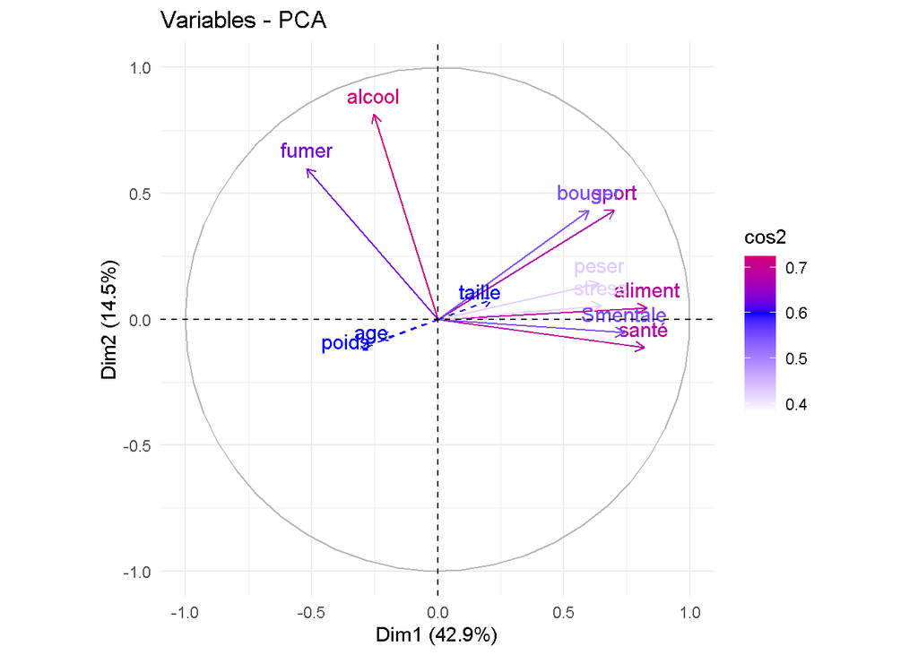

```r
fviz_pca_var(res.pca, col.var="cos2") +
  scale_color_gradient2(low="white", mid="blue",
                        high="red", midpoint=0.6) +
  theme_minimal()
```

```r
#légende :
#sport=je pratique du sport
#aliment=je fais attention à mon alimentation
#sommeil=je.dors.au.moins.7.heures.par.jours.
#stress=j'essaie toujours de gérer mon stress
#fumer= je fume régulièrement des cigarettes
#alcool = je bois régulièrement de l'alcool
#santé= je fait attention à ma santé et je suis les recommandations médical
#Smentale= je fais attention à ma santé mentale(je vois des amis et je pratique des activité qui me font du bien)
#bouger= j'essaie de me déplacer à pied
#peser= je me pese regulierement pour faire attention à mon poid
```

### interprétation variable-axe:

-smentale, aliment et santé sont corrélé positivement au premier axe, avec des cos2 respectivement égale à (0.54782911,0.68809571,0.67296619) on pourrait appeler cet axe équlibre de vie

-alcool est corrélé positivement au deuxième axe , avec un cos2 égale à 0.66, on pourrait donc appelé cet axe alcool

### interprétation variable-variable:

-alcool et fumer sont positivement corrélé , ce qui signifie plus un undividu fume plus il est susceptible de boire .

-smentale, aliment et santé sont corrélé positivement eux à deux ce qui signifie que plus un individu fait attention a sa santé , plus il fait attention a sa santé mentale et plus il fait attention à son alimentation .

-age et poids sont corrélé positivement, ce qui signifie que plus un individu est agée plus il est susceptible d’avoir un poids important.

-bouger et sport sont corrélé positivement , ce qui signifie que plus un individu fait du sport et plus il favorise le déplacement à pied

-âge et poids sont corrélés négativement à bouger et sport , ce qui signifie que plus un individu est agée et a un poids important et moins il est susceptible à faire du sport et à favoriser le deplacement à pied

## 2)5)Interprétation de la carte des individus

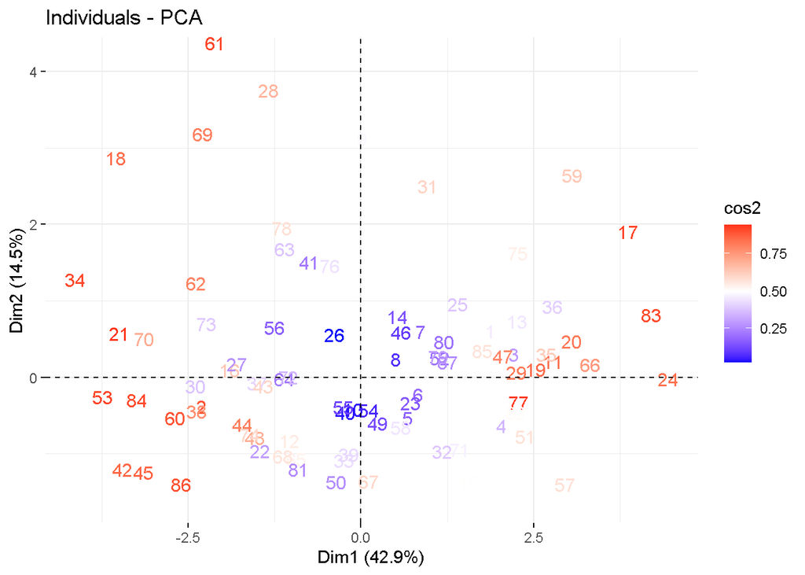

```r
fviz_pca_ind(res.pca,geom = "text",col.ind="cos2")+
scale_color_gradient2(low="blue", mid="white",
                      high="red", midpoint=0.5)
```

On distingue dans ce plan factoriel les groupes suivants :

les groupes qui ont un bon équilibre de vie et qui ne boivent pas de l’alcool (comme l’individu 24) les groupes qui ont un mauvais équilibre de vie et qui ne boivent pas d’alcool (comme l’individu 53)

les groupes qui ont un mauvais équilibre de vie et qui boivent de l’alcool (comme l’individu 18)

on distingue aussi quelques individus exceptionnels comme: -l’individu 17 qui bois de l’alcool de manière modéré et qui a un bon équilibre de vie

###variable qualitative supplémentaire(sexe):

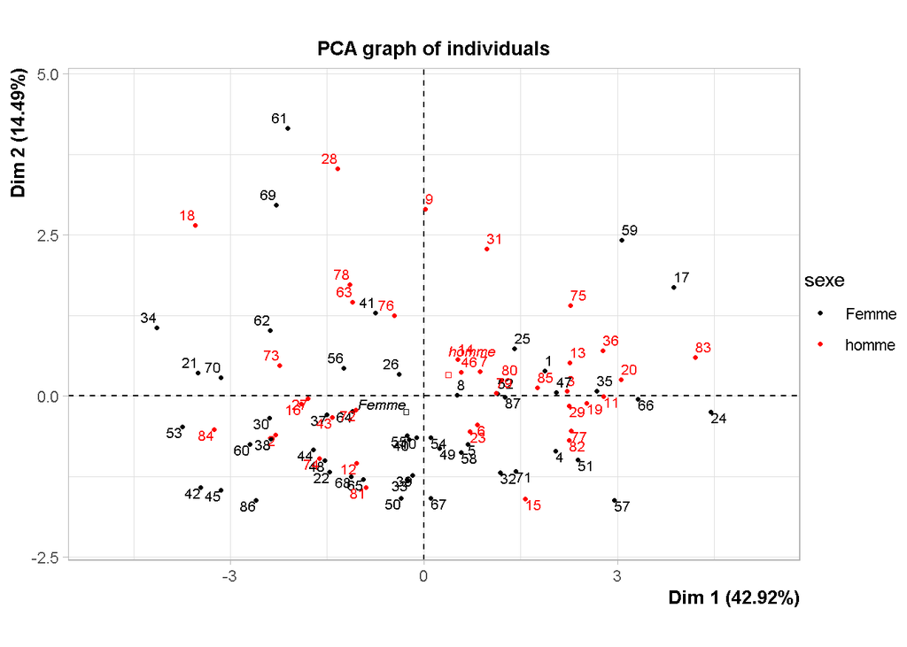

```r
plot.PCA(res.pca, axes=c(1, 2), choix="ind", habillage=11, cex=0.7)
```

Homme a une coordonnée plus élevé sur l’axe 1 et 2 que la femme: ce qui signifie qu’en général l’homme bois de l’alcool plus que la femme et que l’homme a un équilibre de vie mieux que la femme.

## 3)ACP sur le bloc alimentation

## 3)1)Intêret de l’acp:

Etude des individus : deux individus sont proches s’ils ont une alimentation similaires. On s’intéresse à la variabilité entre individus. Y a-t-il des similarités entre les individus pour toutes les variables ? Peut-on établir des profils d’individu ? Peut-on opposer un groupe d’individus à un autre ?

Etude des variables : on étudie les liaisons linéaires entre les variables. Les objectifs sont de résumer la matrice des corrélations et de chercher des variables synthétiques: peut-on résumer l’alimentation des individus par un petit nombre de variables ?

Lien entre les deux études : peut-on caractériser des groupes d’individus par des variables ?

## 3)2)Pertinence de l’acp

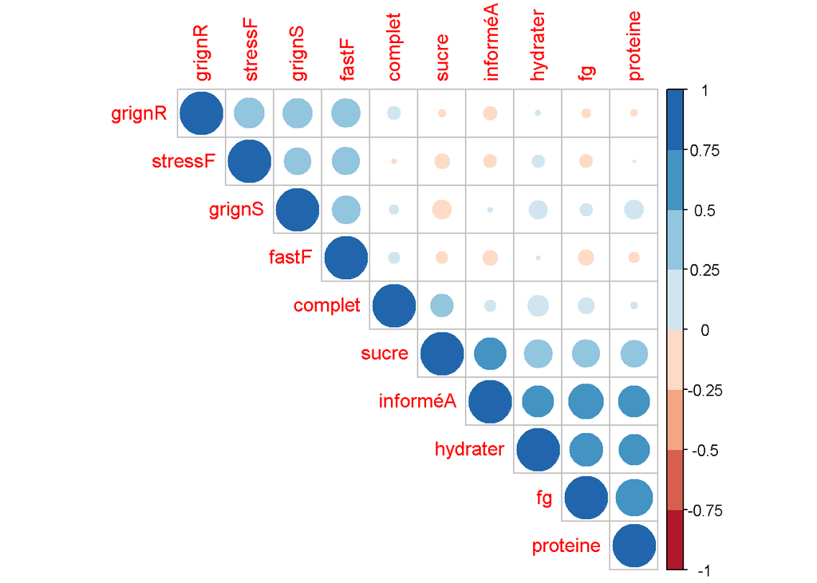

```r
library(corrplot)
X=as.matrix(data[,c(11:20)])
M<-cor(X)
library(RColorBrewer)
corrplot(M, type="upper", order="hclust", col=brewer.pal(n=8, name="RdBu"))
```

les variables sont significativement corrélées , notre ACP est donc pertinente.

```r
library(FactoMineR)
library(factoextra)

res.pca2=PCA(data[,c(11:20,32:35)],ncp = 5,quanti.sup = 12:14,quali.sup=11,graph=F) #sexe, age, poids et taille sont des variables supplémentaires
```

## 3)3)Choix du nombre d’axe

```r
head(res.pca2$eig)
```

```
##        eigenvalue percentage of variance cumulative percentage of variance
## comp 1  3.2405530              32.405530                          32.40553
## comp 2  2.3954751              23.954751                          56.36028
## comp 3  1.1139439              11.139439                          67.49972
## comp 4  0.7395865               7.395865                          74.89559
## comp 5  0.5938270               5.938270                          80.83386
## comp 6  0.5441491               5.441491                          86.27535
```

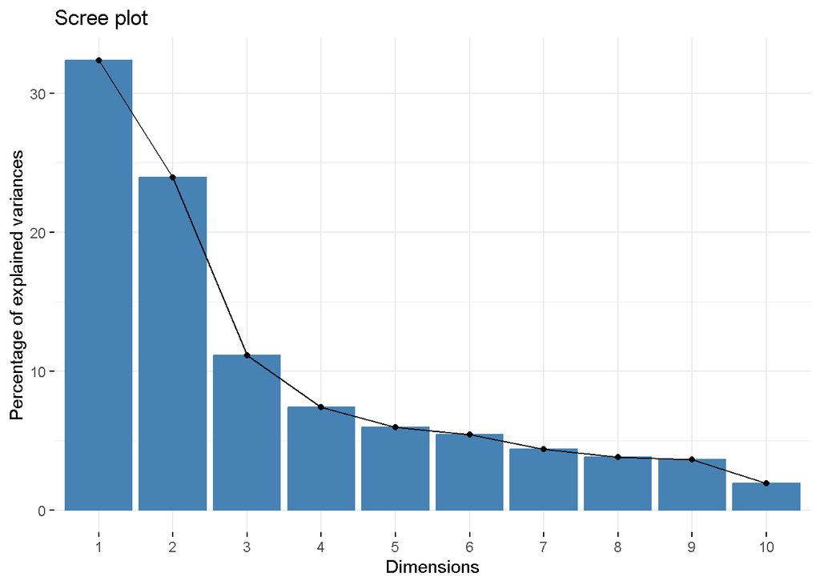

```r
fviz_screeplot(res.pca2, ncp=10)
```

1. Critère de kaiser : on remarque qu’il y a 3 axes dont les valeurs propres sont supérieures à 1 donc on retient 3 axes d’après ce critère.
2. Critère du taux d’inertie cumulée : On remarque que le taux d’inertie cumulé des 2 premiers axes est de 56.4% qui est un taux important compte tenu du fait que nous avons 10 variables : on va donc, d’après ce critère, retenir les 2 premiers axes.
3. Critère du coude : On remarque que le coude se trouve au niveau du troisième axe (voir la figure Scree plot), d’après ce critère, on peut retenir les 2 premiers axes.

Conclusion:En faisant une sorte de vote des 3 critères on devrait retenir les 2 premiers axes.

## 3)4)Interprétation de la carte des variables

```r
res.pca2$var$coord # visualisation des coordonnées
```

```
##                Dim.1       Dim.2       Dim.3       Dim.4        Dim.5
## fg        0.86339578  0.05124739 -0.18324888 -0.12840461  0.003033692
## proteine  0.78537615  0.14559128 -0.32961280 -0.11872267  0.055942344
## sucre     0.69794296 -0.08601238  0.39829372  0.45043184  0.108776753
## complet   0.25428759  0.14308503  0.84323430 -0.39409372 -0.091441721
## hydrater  0.76272293  0.23157193  0.05266568 -0.09662185 -0.198639069
## grignS    0.03523614  0.77933347 -0.22977409 -0.40571005  0.097832400
## fastF    -0.17335278  0.72850513  0.12625558  0.13735847  0.532689604
## informéA  0.82486085 -0.02267557 -0.09798023  0.19888499  0.081970833
## grignR   -0.11743683  0.77572161  0.12533310  0.19673435 -0.063215004
## stressF  -0.13882579  0.74149604 -0.07223866  0.28238552 -0.476436880
```

```r
res.pca2$var$cos2  # visualisation du cos2
```

```
##                Dim.1        Dim.2       Dim.3       Dim.4        Dim.5
## fg       0.745452268 0.0026262954 0.033580152 0.016487744 9.203286e-06
## proteine 0.616815697 0.0211968197 0.108644600 0.014095073 3.129546e-03
## sucre    0.487124377 0.0073981291 0.158637890 0.202888842 1.183238e-02
## complet  0.064662177 0.0204733267 0.711044083 0.155309858 8.361588e-03
## hydrater 0.581746266 0.0536255608 0.002773674 0.009335782 3.945748e-02
## grignS   0.001241586 0.6073606512 0.052796134 0.164600647 9.571179e-03
## fastF    0.030051186 0.5307197292 0.015940471 0.018867348 2.837582e-01
## informéA 0.680395416 0.0005141817 0.009600125 0.039555240 6.719217e-03
## grignR   0.013791410 0.6017440233 0.015708385 0.038704404 3.996137e-03
## stressF  0.019272599 0.5498163708 0.005218424 0.079741581 2.269921e-01
```

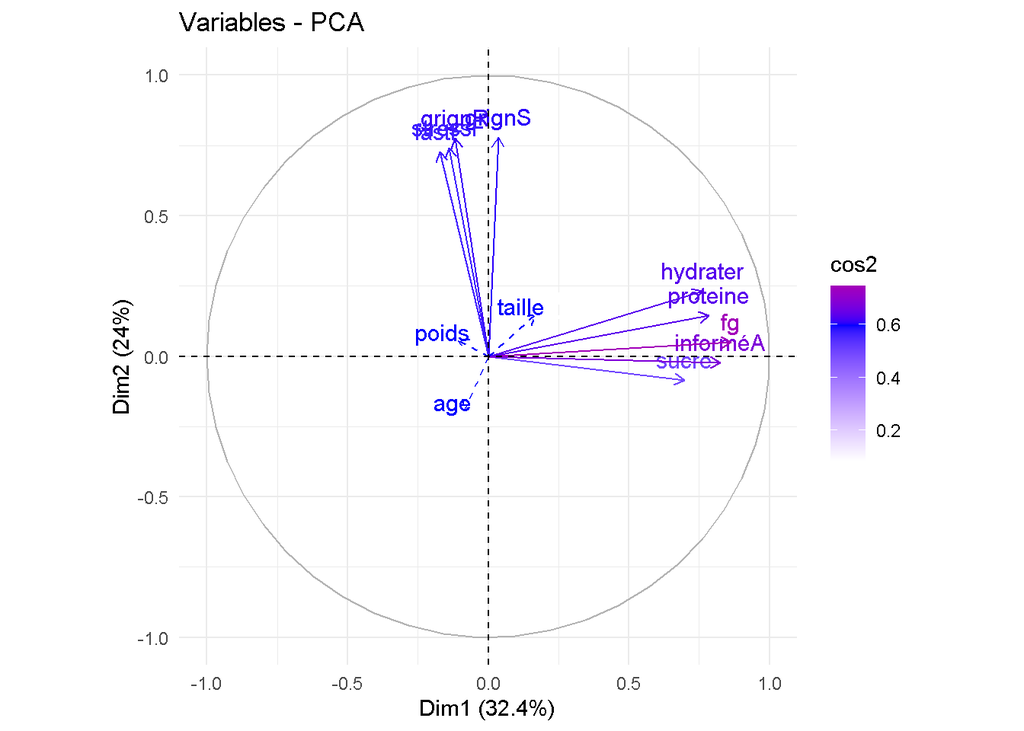

```r
fviz_pca_var(res.pca2, col.var="cos2") +
  scale_color_gradient2(low="white", mid="blue",
                        high="red", midpoint=0.6) +
  theme_minimal()
```

```r
#légende :
#fg=je consomme des fruits et des légumes
#proteine=je consomme une bonne variété de sources de protéine
#sucre=je limite ma consommation de sucre ajouté
#complet=je privilège les aliments complet(farine complète , pattes complète)
#hydrater= je m'hydrate bien
#grigns = j'ai tendance à grignoter le soir
#fastF= j'ai tendance à manger des fast-food
#informéA= je suis bien informé sur les choix alimentaires sains
#grignR= je grignote entre les repas
#stressF= j'utilise souvent la nourriture pour gérer le stress ou les émotions
```

### interprétation variable-axe:

-le premier axe est positivement corrélé à hydrater, proteine,fg,informéA avec de cos2 respectivement égales à(0.58,0.61,0.74,0.68). On pourrait appeler cete axe alimentation responsable

-le deuxieme axe est positivement corrélé à grignS,fastF,grignR,stressF avec des cos2 respectivement égale à(0.60,0.53,0.60,0.54) .On pourrait appeler cette axe comportement de grignotage

### interprétation variable-variable:

-les variables hydrater, proteine,fg,informéA,sucre sont positivement corrélés entre eux , ce qui signifie que plus un individu est informé sur les choix des alimentations saines plus il s’alimente de proteine , de fruits , de legume et pus il lmite sa consommation de sucres ajoutés

- les variables grignS,fastF,grignR,stressF sont positivement corrélés entre eux , ce qui signifie que plus un individu grignote entre les repas ou le soir, plus il a tendance a manger des fastFood et gerer le stress par la nourriture .

## 3)5)Interprétation de la carte des individus

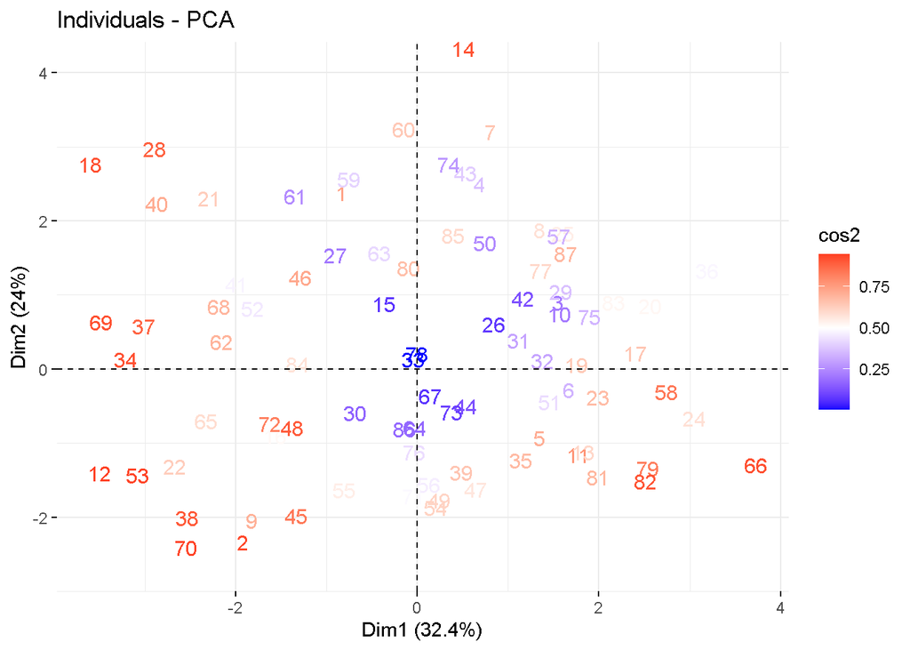

```r
fviz_pca_ind(res.pca2,geom = "text",col.ind="cos2")+
scale_color_gradient2(low="blue", mid="white",
                      high="red", midpoint=0.5)
```

On distingue dans ce plan factoriel les groupes suivants :

-le groupe d’individus qui ont une alimentation équilibré et qui n’ont pas un comportement de grignotage comme l’individu 66.

-le groupe d’individus qui ont une alimentation pas équilibré et qui n’ont pas un comportement de grignotage comme l’individu 12.

-le groupe d’individus qui ont une alimentation pas équilibré et qui ont un comportement de grignotage comme l’individu 28.

-on peut aussi distinguer des individus qui sortent du lot comme l’individu 14 qui a une alimentation un peu équilibré et qui possède un comportement de grignotage.

###variable qualitative supplémentaire(sexe):

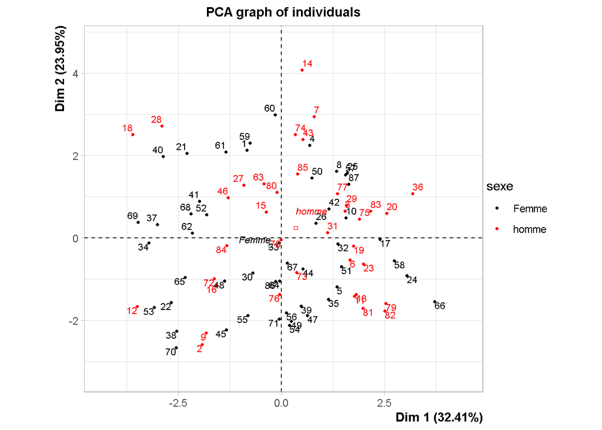

```r
plot.PCA(res.pca2, axes=c(1, 2), choix="ind", habillage=11, cex=0.7)
```

y-a-t-il dépendance entre les différentes variables ´ Si oui quels types d’associations existent entre ces variables ? Peut-on regrouper des individus et les caractériser par des variables.

## 4) ACM

```r
library(FactoMineR)
library(factoextra)
library(FactoInvestigate)
dataACM=data[,c(21:31)]
head(dataACM)
```

```
##    Tg  OE  OV  Tc allergie Mchron SSPORT FSpoids fumez alcool surpoids
## 1 non non non non      non    non    non     non   non    oui      non
## 2 non non non non      oui    non    non     oui   oui    oui      non
## 3 non non non non      non    oui    non     non   non    non      oui
## 4 non non non non      non    non    non     oui   non    non      non
## 5 non non non non      non    non    non     oui   non    non      non
## 6 non non non non      non    non    non     oui   oui    oui      non
```

```r
summary(dataACM)
```

```
##       Tg                 OE                 OV                 Tc
##  Length:87          Length:87          Length:87          Length:87
##  Class :character   Class :character   Class :character   Class :character
##  Mode  :character   Mode  :character   Mode  :character   Mode  :character
##    allergie            Mchron             SSPORT            FSpoids
##  Length:87          Length:87          Length:87          Length:87
##  Class :character   Class :character   Class :character   Class :character
##  Mode  :character   Mode  :character   Mode  :character   Mode  :character
##     fumez              alcool            surpoids
##  Length:87          Length:87          Length:87
##  Class :character   Class :character   Class :character
##  Mode  :character   Mode  :character   Mode  :character
```

## 4)2)Choix du nombre d’axe

```r
res.mca = MCA (dataACM, graph = FALSE)
res.mca$eig
```

```
##        eigenvalue percentage of variance cumulative percentage of variance
## dim 1  0.17962334              14.113262                          14.11326
## dim 2  0.14877302              11.689309                          25.80257
## dim 3  0.13161114              10.340876                          36.14345
## dim 4  0.11350790               8.918478                          45.06192
## dim 5  0.10050933               7.897161                          52.95909
## dim 6  0.09304721               7.310853                          60.26994
## dim 7  0.09130813               7.174210                          67.44415
## dim 8  0.08842270               6.947498                          74.39165
## dim 9  0.07617228               5.984965                          80.37661
## dim 10 0.06817422               5.356546                          85.73316
## dim 11 0.05917862               4.649749                          90.38291
## dim 12 0.04774140               3.751110                          94.13402
## dim 13 0.04248101               3.337794                          97.47181
## dim 14 0.03217696               2.528190                         100.00000
```

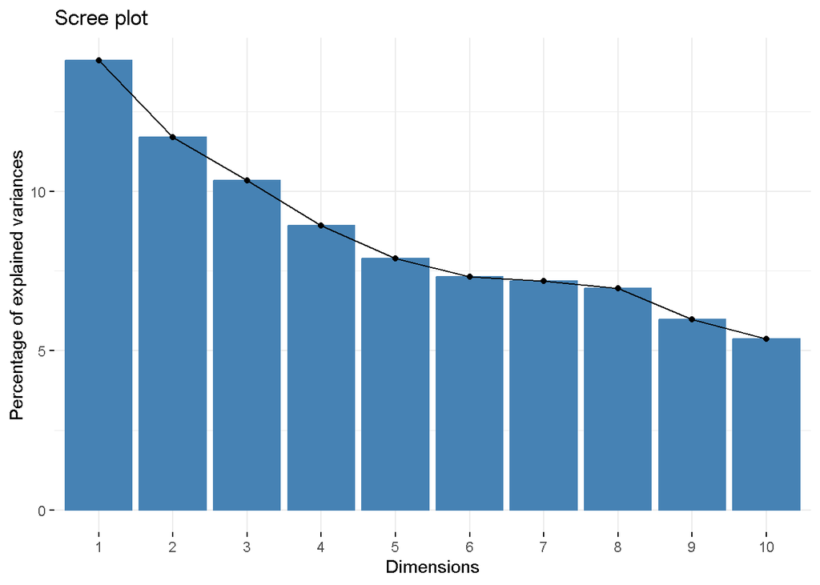

```r
fviz_screeplot(res.mca)
```

1. Le critère du coude nous donne le choix de deux axes(le coude est situé aux deuxième axe).
2. le critère du taux d’inertie cumulé nous permettent de choisir les 4 axes avec un taux cumulé de 45% ce qui n’est pas mal pour 11 variables
3. le critère de la moyenne noux permettent de choisir les axes avec les valeurs propres qui sont supérieur à 1/11=0.09 et on a donc 7 axes

Conclusion: on choisit le nombre d’axe qui est presque égale a la moyenne des nombres d’axes des trois critères et qui est égale à 4 axes.